# Case Studies in R

`` ## Warning: Removed 2 rows containing missing values or values outside the scale range ## (`geom_point()`). ``

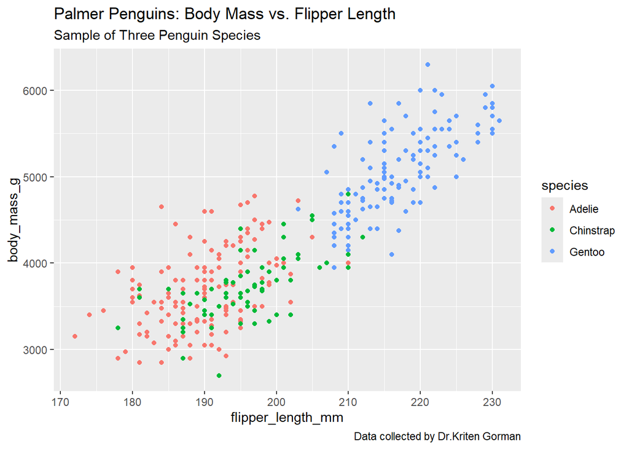

`r ggplot(data = penguins) + geom_point(mapping = aes(x=flipper_length_mm, y=body_mass_g, colour = species)) + labs(title = "Palmer Penguins: Body Mass vs. Flipper Length", subtitle = "Sample of Three Penguin Species", caption = "Data collected by Dr.Kriten Gorman") + annotate("text", x=220, y=3500, label = "The Gentoos are the largest")`

`` ## Warning: Removed 2 rows containing missing values or values outside the scale range ## (`geom_point()`). ``

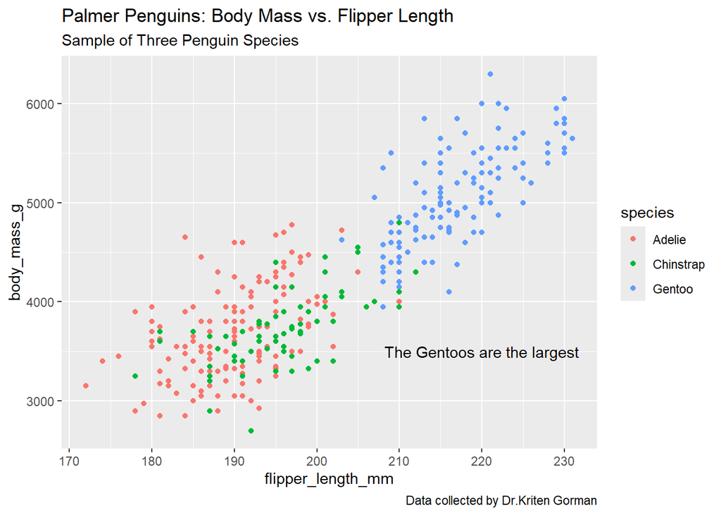

`r ggplot(data = penguins) + geom_point(mapping = aes(x=flipper_length_mm, y=body_mass_g, colour = species)) + labs(title = "Palmer Penguins: Body Mass vs. Flipper Length", subtitle = "Sample of Three Penguin Species", caption = "Data collected by Dr.Kriten Gorman") + annotate("text", x=220, y=3500, label = "The Gentoos are the largest", color = "purple")`

`` ## Warning: Removed 2 rows containing missing values or values outside the scale range ## (`geom_point()`). ``

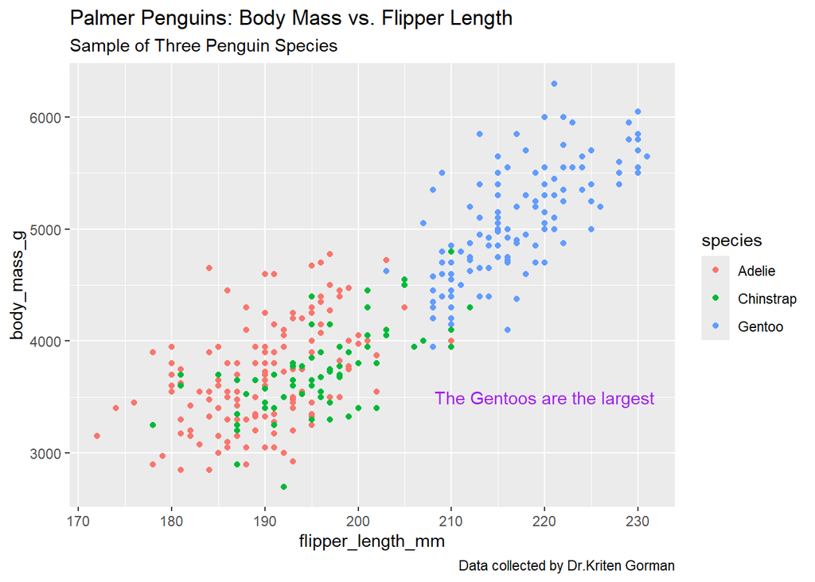

`r ggplot(data = penguins) + geom_point(mapping = aes(x=flipper_length_mm, y=body_mass_g, colour = species)) + labs(title = "Palmer Penguins: Body Mass vs. Flipper Length", subtitle = "Sample of Three Penguin Species", caption = "Data collected by Dr.Kriten Gorman") + annotate("text", x=220, y=3500, label = "The Gentoos are the largest", color = "purple", fontface="bold", size=4.5)`

`` ## Warning: Removed 2 rows containing missing values or values outside the scale range ## (`geom_point()`). ``

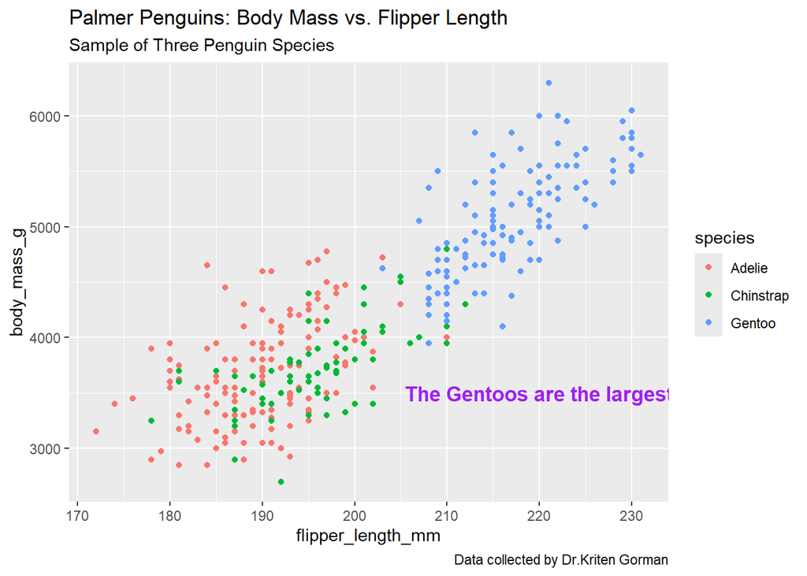

`r ggplot(data = penguins) + geom_point(mapping = aes(x=flipper_length_mm, y=body_mass_g, colour = species)) + labs(title = "Palmer Penguins: Body Mass vs. Flipper Length", subtitle = "Sample of Three Penguin Species", caption = "Data collected by Dr.Kriten Gorman") + annotate("text", x=220, y=3500, label = "The Gentoos are the largest", color = "purple", fontface="bold", size=4.5, angle=25)`

`` ## Warning: Removed 2 rows containing missing values or values outside the scale range ## (`geom_point()`). ``

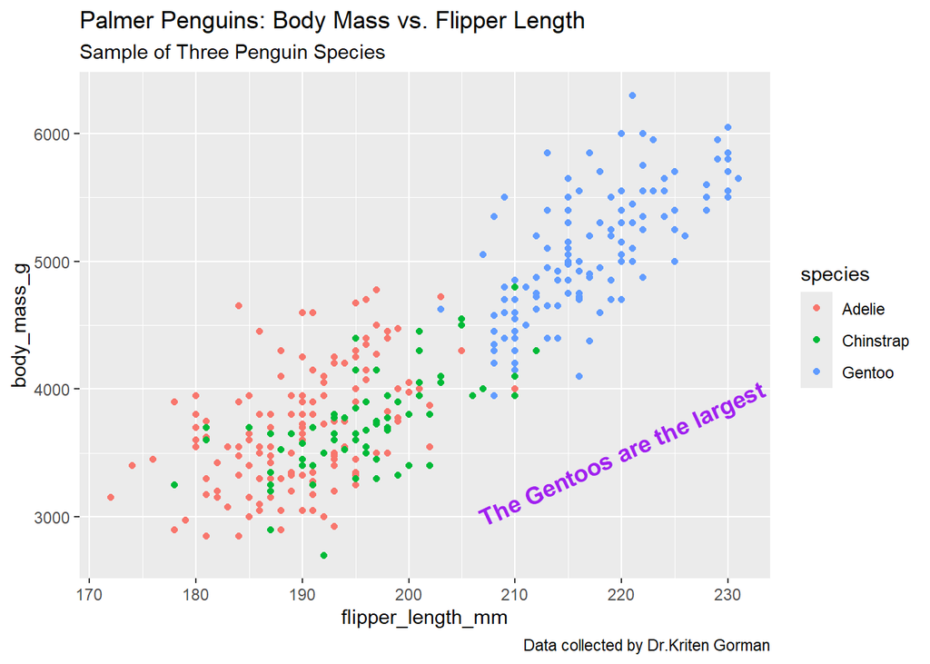

`r P <- ggplot(data = penguins) + geom_point(mapping = aes(x=flipper_length_mm, y=body_mass_g, colour = species)) + labs(title = "Palmer Penguins: Body Mass vs. Flipper Length", subtitle = "Sample of Three Penguin Species", caption = "Data collected by Dr.Kriten Gorman")`

`r P + annotate("text", x=220, y=3500, label = "The Gentoos are the largest")`

`` ## Warning: Removed 2 rows containing missing values or values outside the scale range ## (`geom_point()`). ``

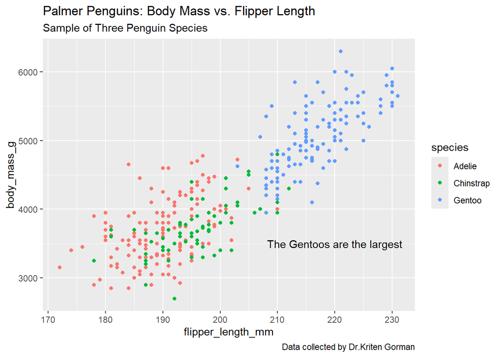

# Saving your visualizations

- Export option Plotting window > Export > save as an image/ save as a pdf > png/jpg > click save > check files tab
- ggsave() option

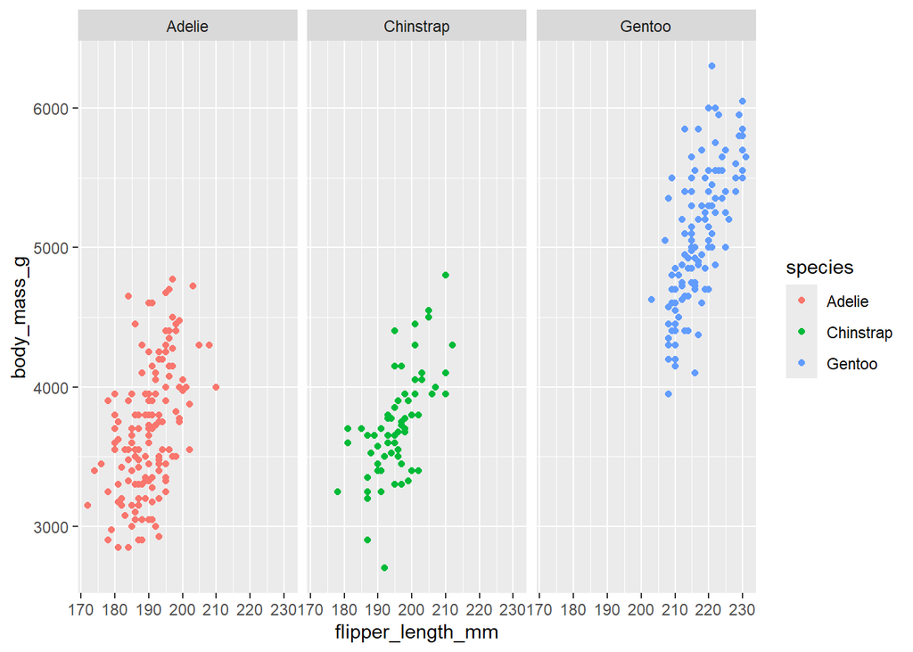

```r
library(ggplot2)
library(palmerpenguins)

ggplot(data = penguins) +
  geom_point(mapping = aes(x=flipper_length_mm, y=body_mass_g, color = species)) +
  facet_wrap(~species)
```

```r
ggsave("Three Penguin Species.png")
```